# Functional magnetic resonance imaging signal modelling and contrasts

## The example of manual praxis tasks

This notebook presents fitting modeled hemodynamic response function (HRF) for a single trial of planning functional grasps condition. This single-trial example uses 17 volumes of BOLD fMRI signal (17 signal time points). The signal comes from one of the runs of one of the participants. The expected signal timecourse was already modeled with FSL and it is stored in a `design.mat` file.

### General introduction

What will be presented here can be summarized on the Figure below:

[figure not shown]

Figure adapted from: [Eloyan et al., 2014 - *Analytic Programming with fMRI Data: A Quick-Start Guide for Statisticians Using R*](https://www.researchgate.net/publication/260448116_Analytic_Programming_with_fMRI_Data_A_Quick-Start_Guide_for_Statisticians_Using_R/figures?lo=1&utm_source=google&utm_medium=organic).

We selected a single voxel, extracted signal timecourse from it, and we will be comparing that signal with the expected timecourse, as predicted with the general linear model (GLM).

### More information about the data

The best fit voxel location (19, 43, 25) was already known, based on a separate analysis.

The signal comes from functional grasp planning task, see:

Przybylski, Ł., & Kroliczak, G. (2017). Planning Functional Grasps of Simple Tools Invokes the Hand-independent Praxis Representation Network: An fMRI Study. Journal of the International Neuropsychological Society, 23(02), 108–120. https://doi.org/10.1017/S1355617716001120

and

Buchwald, M., Przybylski, Ł., & Kroliczak, G. (2018). Decoding Brain States for Planning Functional Grasps of Tools: A Functional Magnetic Resonance Imaging Multivoxel Pattern Analysis Study. Journal of the International Neuropsychological Society, 24(10), 1013–1025. https://doi.org/10.1017/S1355617718000590

This example uses a native `numpy` module to model the signal and calculate a parameter estimate.

For example of modelling the signal (here only fitting is presented) see: http://www.jarrodmillman.com/rcsds/lectures/convolution_background.html

```python
import numpy as np
from nilearn import image
import matplotlib.pyplot as plt
```

```python
# Load matrix file
design = np.loadtxt('data/single_trial/design.mat')
design
```

```
array([ -8.74696 ,   1.539723,  35.68112 ,  49.17466 ,  30.03663 ,
         7.700465,  -5.939874, -12.29698 , -14.20883 , -13.7046  ,
       -12.28538 , -10.89485 ,  -9.90825 ,  -9.333189,  -9.042936,
        -8.912189,  -8.858559])
```

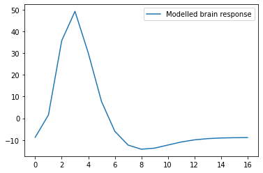

```python
plt.plot(design, label='Modelled brain response')
plt.legend()
plt.show()
```

Acquired signal time-course for a single voxel. This voxel was indicated with FEAT as the one with the best fit to the modelled time-course.

```python
data = image.load_img('data/single_trial/planning.nii.gz').get_fdata()[19, 43, 25, :]
data
```

```
array([12957.16210938, 13013.44042969, 13155.16503906, 13207.12695312,
       13197.60742188, 13034.83984375, 12984.20117188, 12925.64941406,
       12927.640625  , 13016.82519531, 12982.36914062, 13018.98144531,
       13012.48925781, 13012.43847656, 12997.41308594, 12943.59960938,
       12981.78222656])
```

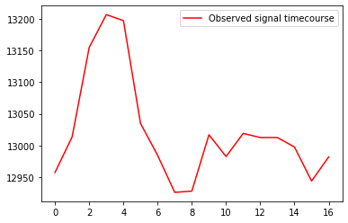

```python
plt.plot(data, 'r', label='Observed signal timecourse')
plt.legend()
plt.show()
```

```python
X = np.matrix([np.ones(design.shape[0]), design]).T
X
```

```
matrix([[  1.      ,  -8.74696 ],
        [  1.      ,   1.539723],
        [  1.      ,  35.68112 ],
        [  1.      ,  49.17466 ],
        [  1.      ,  30.03663 ],
        [  1.      ,   7.700465],
        [  1.      ,  -5.939874],
        [  1.      , -12.29698 ],
        [  1.      , -14.20883 ],
        [  1.      , -13.7046  ],
        [  1.      , -12.28538 ],
        [  1.      , -10.89485 ],
        [  1.      ,  -9.90825 ],
        [  1.      ,  -9.333189],
        [  1.      ,  -9.042936],
        [  1.      ,  -8.912189],
        [  1.      ,  -8.858559]])
```

```python
y = np.matrix(data).T
y
```

```
matrix([[12957.16210938],
        [13013.44042969],
        [13155.16503906],
        [13207.12695312],
        [13197.60742188],
        [13034.83984375],
        [12984.20117188],
        [12925.64941406],
        [12927.640625  ],
        [13016.82519531],
        [12982.36914062],
        [13018.98144531],
        [13012.48925781],
        [13012.43847656],
        [12997.41308594],
        [12943.59960938],
        [12981.78222656]])
```

```python
beta_hat = np.linalg.inv(X.T.dot(X)).dot(X.T).dot(y)

print('Constant (intercept): %f' % beta_hat[0])
print('Parameter estimate (PE): %f' % beta_hat[1])
```

```
Constant (intercept): 13021.690085
Parameter estimate (PE): 4.095670
```

```python
model_fit = X[:,1] * beta_hat[1] + beta_hat[0]
residuals = y - model_fit

R_squared = 1 - (np.power((y-model_fit), 2).sum()
                 /
                 np.power((y - y.mean()), 2).sum())

print('R squared: %s' % R_squared)
```

```
R squared: 0.860170571106656
```

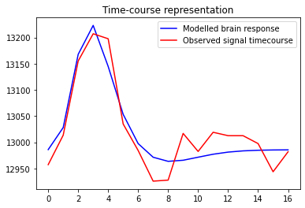

```python
plt.title('Time-course representation')
plt.plot(model_fit, color='b', label='Modelled brain response')
plt.plot(data, color='r', label='Observed signal timecourse')
plt.legend()
plt.show()
```

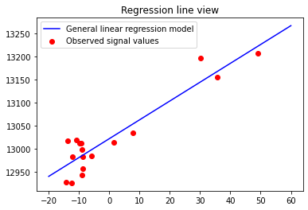

```python
xx = np.linspace(-20, 60, 2)
yy = np.array(beta_hat[0] + beta_hat[1] * xx)

plt.title('Regression line view')
plt.plot(xx, yy.T, color='b', label='General linear regression model')
plt.scatter(design, data, color='r', label='Observed signal values')

plt.legend()
plt.show()
```

## Single figure visualization

Both plots on a single figure as a summary of the notebook.

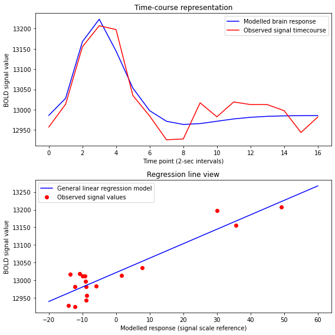

```python
plt.rcParams['figure.figsize'] = [8, 8]

plt.subplot(2,1,1)
plt.title('Time-course representation')
plt.plot(model_fit, color='b', label='Modelled brain response')
plt.plot(data, color='r', label='Observed signal timecourse')
plt.legend()
plt.xlabel('Time point (2-sec intervals)')
plt.ylabel('BOLD signal value')

plt.subplot(2,1,2)
plt.title('Regression line view')
plt.plot(xx, yy.T, color='b', label='General linear regression model')
plt.scatter(design, data, color='r', label='Observed signal values')
plt.legend()
plt.xlabel('Modelled response (signal scale reference)')
plt.ylabel('BOLD signal value')

plt.tight_layout()

plt.savefig('figures/Figure 1 - Fitting a general linear model.png',
            dpi=300)
plt.savefig('figures/Figure 1 - Fitting a general linear model.pdf',
            dpi=300)

plt.show()
```

## Further reading and additional materials

[figure not shown]

Source: [CREx, Institute of Language, Communication and the Braib (ILCB)](https://blricrex.hypotheses.org/ressources/fmri)

[figure not shown]

Source: [a Medium article by Carsten Klein](https://medium.com/coinmonks/visualizing-brain-imaging-data-fmri-with-python-c68fcd595d5f)

[figure not shown]

Source: [Chou et al., - *IEEE Transactions on Medical Imaging*](https://www.researchgate.net/publication/261222773_Voxel_Selection_Framework_in_Multi-Voxel_Pattern_Analysis_of_fMRI_Data_for_Prediction_of_Neural_Response_to_Visual_Stimuli)